# day4.Rmd

Philip Sweet

2023-06-01

## Intro to R Day 4 Worksheet

In this worksheet we will demonstrate writing a report using rmarkdown. In this study, we are looking to identify novel antibiotics agaisnt *E. infectius* . There will be two sections to this worksheet, working with two seperate datasets.

1. Screen four novel fungal peptides for toxicity against *E. infectius* to identify the most promising peptide.
2. Examine the impact of the peptide on cell growth rates

For this first experiment, you grew up 3 biological replicates of *E. infectius*, split them, and treated each with one of the four fungal peptides (Fo114, Fo321,Fo012, Fo203) or with PBS (negative control). You then plated the treated cultures and plated them in technical triplcate. The follwoing morning, counted the number of *E. infectius* Colony Forming Units (CFU) that grew.

## 1.Screen for toxin peptides using CFU Data

### 1.1 Read in the CFU data

The cell survival data is stored within the ‘data’ folder, for this reason, we have to point R to the location of the file.

*Goal:* To identify a fungal peptide that decreases the number of CFU of *E. infectius*.

*Data:* Counts of CFU have been collected after exposure of *E. infectius* to four different fungal peptides (Fo114, Fo321,Fo012, Fo203) and a negative control (PBS). Data was collected in biological triplicate and technical triplate, for a total of 9 counts per treatment. The relative ratio will be calculated for each treatment to correct for the differences in CFU between biological replicates. A two sample t test will be used to determine if the mean ratio of CFU is different from the PBS control after treatment.

```r
read_csv("Data/CFU_data.csv") -> wide_cfu
head(wide_cfu)
```

```
## # A tibble: 6 × 7
##   BioRep TechRep CFU_Fo114 CFU_Fo321 CFU_Fo012 CFU_Fo203 CFU_PBS
##   <chr>    <dbl>     <dbl>     <dbl>     <dbl>     <dbl>   <dbl>
## 1 A            1       211       318       315       384     320
## 2 A            2       131       310       210       456     331
## 3 A            3       187       330       302       378     315
## 4 B            1        97       305       160       216     180
## 5 B            2        63       212       163       222     185
## 6 B            3        71       150       184       207     173
```

You collected this data before you knew of the wonders of Tidy data. The first step will be to tidy up the data. When you’re complete the dataframe should have 45 rows ‘nrow()’ and new column named ‘Treatment’. *Bonus* Remove the ‘CFU_’ from in front of the peptides. This can be done using mutate() and ‘str_replace()’

### 1.2 Tidy the CFU data

```r
wide_cfu %>%
  pivot_longer(CFU_Fo114:CFU_PBS, values_to = "CFU", names_to = "Treatment" ) %>%
  mutate(Treatment = str_replace(Treatment, "CFU_",""))-> tidy_cfu
```

### 1.3 Plot the raw CFU data

1. Now make a plot showing the distribution of CFU’s per treatment by layering a ‘geom_point()’ over top of a ‘geom_box()’. Color the points by BioRep.
2. Now try using ‘geom_jitter’ instead of geom_point and note the difference, which is more informative?

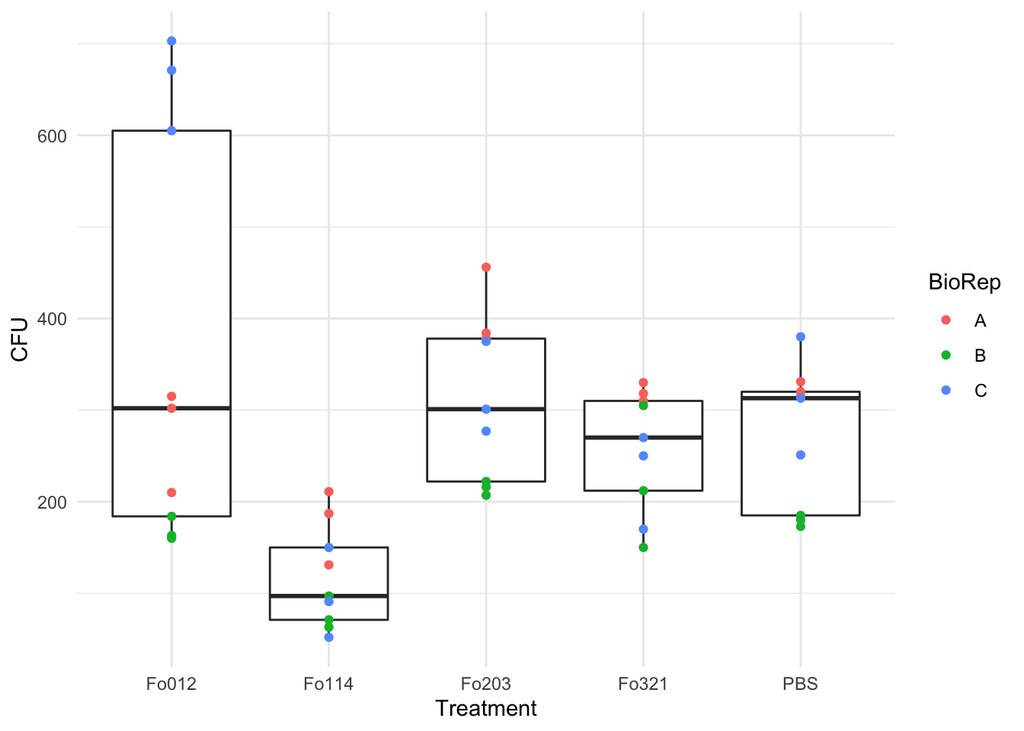

```r
ggplot(tidy_cfu, aes(x =Treatment, y = CFU)) +
  geom_boxplot() +
  geom_point(aes(x = Treatment, y = CFU, color = BioRep)) +
  theme_minimal()
```

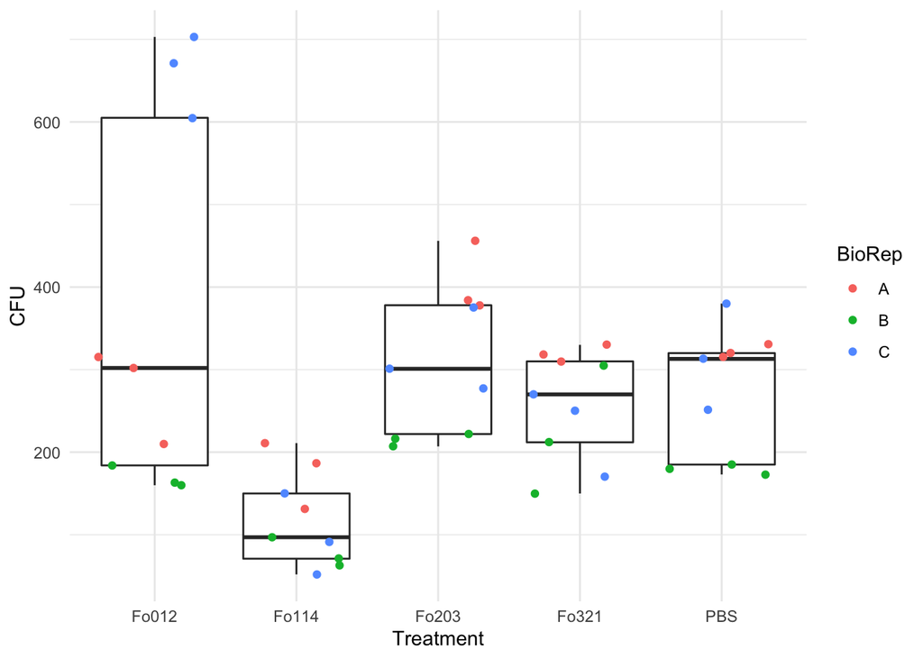

```r
ggplot(tidy_cfu, aes(x =Treatment, y = CFU)) +
  geom_boxplot() +
  geom_jitter(aes(x = Treatment, y = CFU, color = BioRep))+
  theme_minimal()
```

### 1.4 Calculate the Relative Ratio of CFU per Treatment

Now that we have tidy data, we can use tidyverse functions to calculate the impact of each fungal protein on the number of CFU. To do so, you will need to find the mean number of CFU for the negative control (PBS) for each *biological replicate* and then divide each count by it’s respective mean.

1. This can be done multiple ways, but one option is group the data by BioRep and then make a column that contains the mean of the CFU’s of the PBS-treated cells.

*Hint* this can be done using ‘CFU[Treatment == “PBS”]’

```r
tidy_cfu %>%
  group_by(BioRep) %>%
  mutate(PBS_mean = mean(CFU[Treatment == "PBS"]))  -> tidy_cfu

head(tidy_cfu)
```

```
## # A tibble: 6 × 5
## # Groups:   BioRep [1]
##   BioRep TechRep Treatment   CFU PBS_mean
##   <chr>    <dbl> <chr>     <dbl>    <dbl>
## 1 A            1 Fo114       211      322
## 2 A            1 Fo321       318      322
## 3 A            1 Fo012       315      322
## 4 A            1 Fo203       384      322
## 5 A            1 PBS         320      322
## 6 A            2 Fo114       131      322
```

2. Now you can divide each replicate by it’s respective PBS mean, producing a ratio of treatred/untreated CFU. Call this new column of called “Ratio_CFU”.
3. Make a summary table of the mean and standard deviation of ratio_CFU for each Treatment. If you calculated the ratio correctly the mean of Fo321 will be 0.9875
4. Now make the same style of overlayed ‘geom_boxplot’/‘geom_jitter’ as we made above, but using the ratio CFU data. When using ‘geom_boxplots’, outlier’s are represented using black points. Modify the shape of the ‘geom_point()’ so that you can clearly distinguish the individual replicates from the boxplot outlier’s.

```r
tidy_cfu %>%
  mutate(Ratio_CFU = CFU/PBS_mean) ->  tidy_cfu

tidy_cfu %>%
  group_by(Treatment) %>%
  summarize(mean_Ratio = mean(Ratio_CFU), sd_Ratio = sd(Ratio_CFU))
```

```
## # A tibble: 5 × 3
##   Treatment mean_Ratio sd_Ratio
##   <chr>          <dbl>    <dbl>
## 1 Fo012          1.30     0.613
## 2 Fo114          0.429    0.152
## 3 Fo203          1.16     0.156
## 4 Fo321          0.987    0.321
## 5 PBS            1        0.105
```

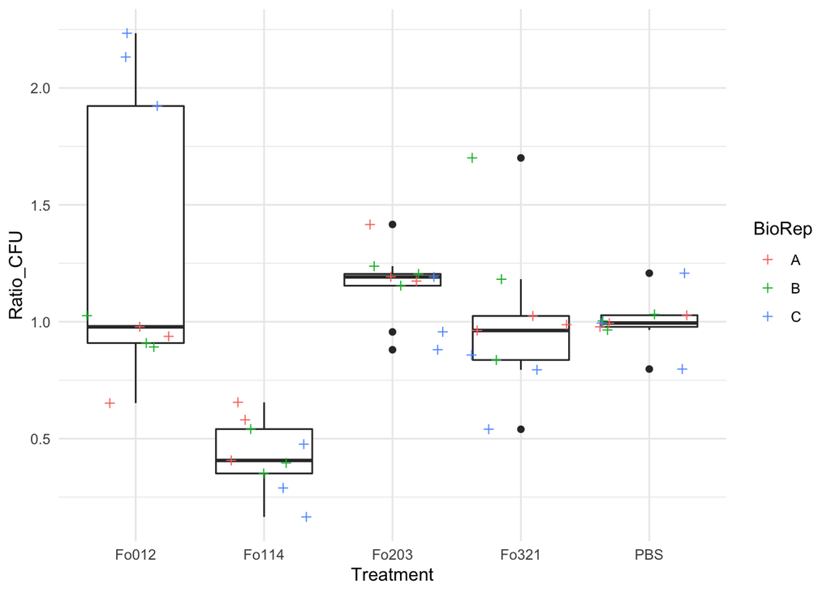

```r
ggplot(tidy_cfu, aes(x =Treatment, y = Ratio_CFU)) +
  geom_boxplot() +
  geom_jitter(aes(x = Treatment, y = Ratio_CFU, color = BioRep), shape = 3) +
  theme_minimal()
```

5. How does the plot for the ratio compare to the plot of the raw counts made in section 1.3?